# BombusCanadaSpatialAnalysis - Spatial Intensity & Spatial Correlations

#### Load Libraries

```r
# Load libraries
library(spatstat)
library(spatstat.geom)
library(spatstat.explore)
library(viridis)
library(RColorBrewer)
```

#### Load Data

```r
# Load data
load("../data/ppp_bombus.Rda")
load("../data/BC_Covariates.Rda")
data_covariates <- DATA
```

### I. Spatial Intensity (First-order Properties)

#### Homogeneous Intensity Estimate

```r
# Rescale to km²
ppp_bombus_km <- rescale(ppp_bombus, 1000, "km")
intensity(ppp_bombus_km)
```

```
## [1] 0.001037687
```

#### Quadrat Counting and Intensity Map

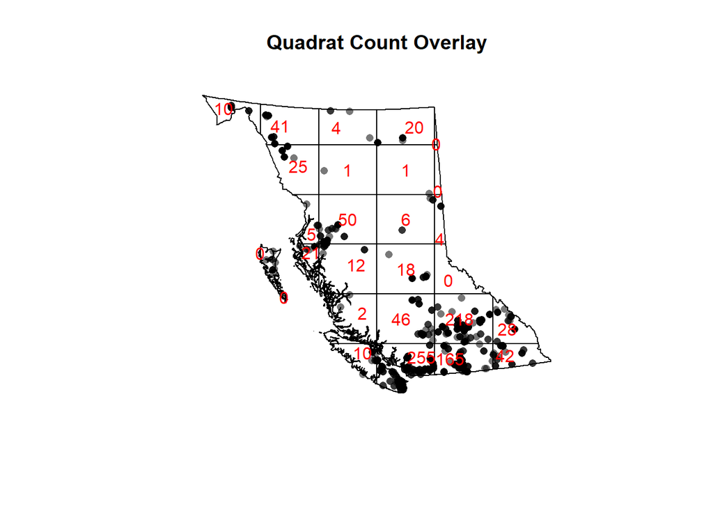

```r
Q <- quadratcount(ppp_bombus, nx = 6, ny = 6)

# Visualize quadrats
plot(ppp_bombus, pch = 16, main = "Quadrat Count Overlay", use.marks = FALSE)
plot(Q, add = TRUE, col = "red")
```

```r
# Intensity per quadrat
intensity(Q)
```

```
## tile
## Tile row 1, col 1 Tile row 1, col 2 Tile row 1, col 3 Tile row 1, col 4
##      5.494798e-10      8.970251e-10      9.286567e-11      4.513562e-10
## Tile row 1, col 5 Tile row 2, col 2 Tile row 2, col 3 Tile row 2, col 4
##      0.000000e+00      5.736513e-10      1.649798e-11      1.649798e-11
## Tile row 2, col 5 Tile row 3, col 2 Tile row 3, col 3 Tile row 3, col 4
##      0.000000e+00      2.978057e-10      8.248988e-10      9.898785e-11
## Tile row 3, col 5 Tile row 4, col 1 Tile row 4, col 2 Tile row 4, col 3
##      4.300713e-10      0.000000e+00      9.391687e-10      2.037649e-10
## Tile row 4, col 4 Tile row 4, col 5 Tile row 5, col 2 Tile row 5, col 3
##      2.969636e-10      0.000000e+00      0.000000e+00      4.583117e-11
## Tile row 5, col 4 Tile row 5, col 5 Tile row 5, col 6 Tile row 6, col 3
##      7.624796e-10      3.601941e-09      1.055552e-09      5.195335e-10
## Tile row 6, col 4 Tile row 6, col 5 Tile row 6, col 6
##      6.428456e-09      4.692918e-09      1.766419e-09
```

The quadrat map reveals strong spatial heterogeneity: some grid cells are densely populated while others are completely empty. This visual evidence contradicts spatial uniformity.

#### Quadrat Test for Complete Spatial Randomness

```r
quadrat.test(ppp_bombus, nx = 6, ny = 6)
```

```
##
##  Chi-squared test of CSR using quadrat counts
##
## data:  ppp_bombus
## X2 = 2371.1, df = 26, p-value < 2.2e-16
## alternative hypothesis: two.sided
##
## Quadrats: 27 tiles (irregular windows)
```

The test yields an extremely small p-value (p < 2.2e-16), statistically rejecting CSR. This supports the existence of spatial clustering.

#### Kernel Density Estimation

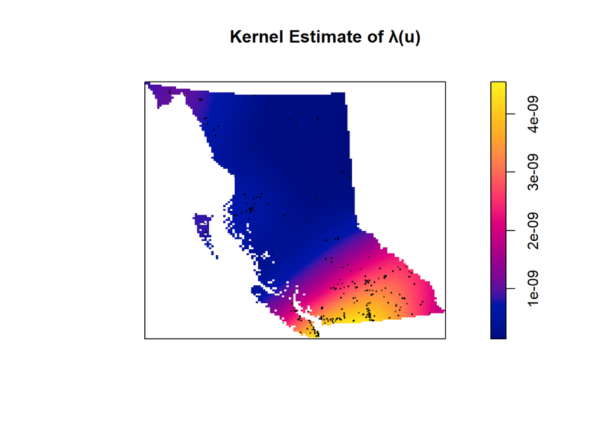

```r
lambda_kde <- density(ppp_bombus)

plot(lambda_kde, main = "Kernel Estimate of λ(u)")
plot(ppp_bombus, add = TRUE, pch = 16, cex = 0.3, use.marks = FALSE)
```

Kernel smoothing shows that Bombus records are concentrated in the southwest and southeast. Northern BC remains largely empty, indicating regional intensity bias.

#### Bandwidth Sensitivity Comparison

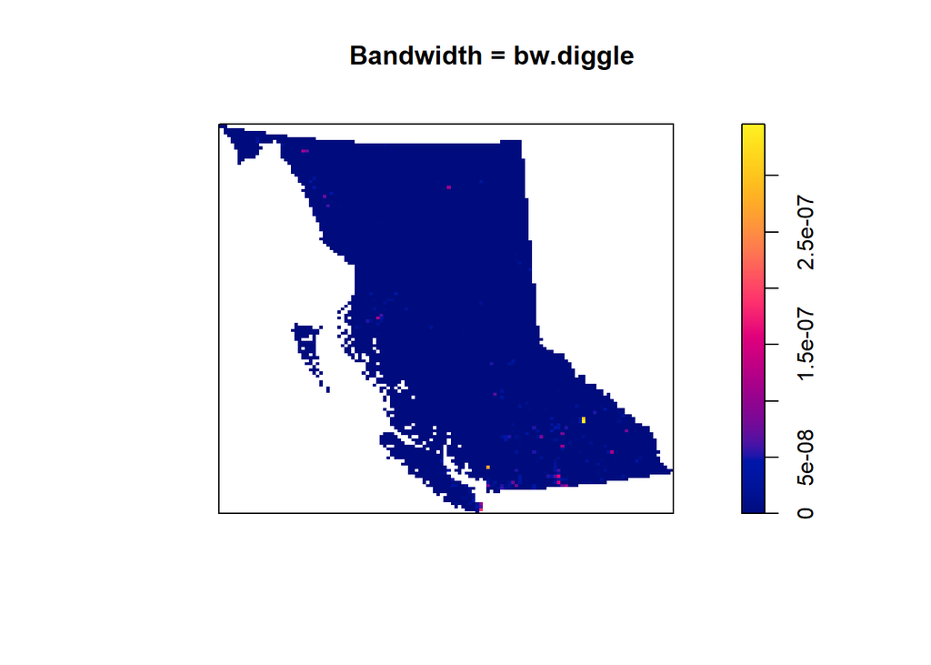

```r
par(mfrow = c(1,1))
plot(density(ppp_bombus, sigma = bw.diggle), main = "Bandwidth = bw.diggle")
```

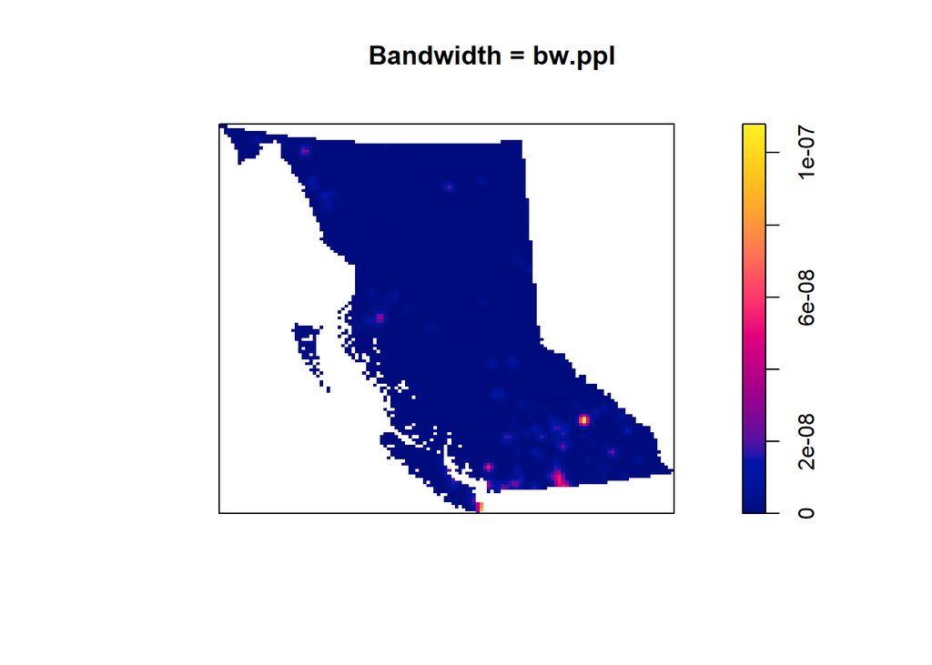

```r
plot(density(ppp_bombus, sigma = bw.ppl), main = "Bandwidth = bw.ppl")
```

Using different bandwidths changes the degree of smoothing, but hotspot patterns remain stable, confirming the robustness of detected spatial trends.

#### Hotspot Detection (Scan Test)

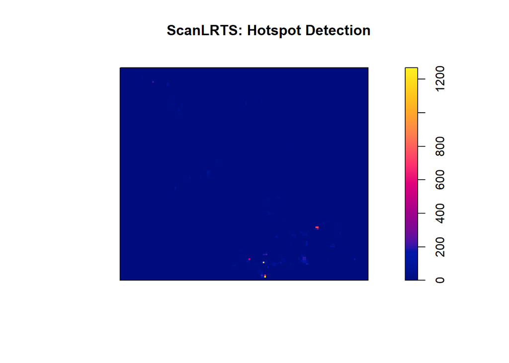

```r
R <- bw.ppl(ppp_bombus)
LR <- scanLRTS(ppp_bombus, r = R)

plot(LR, main = "ScanLRTS: Hotspot Detection")
```

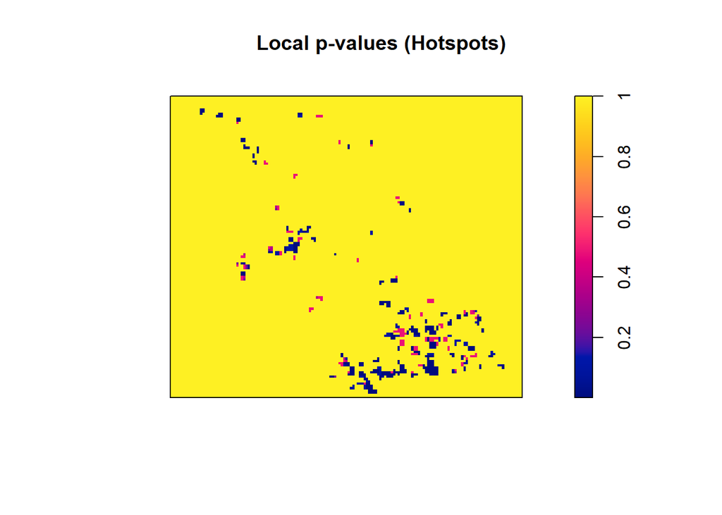

```r
pvals <- eval.im(pchisq(LR, df = 1, lower.tail = FALSE))
plot(pvals, main = "Local p-values (Hotspots)")
```

Significant hotspots are detected in southern BC. The scan test identifies localized clusters where observed intensity exceeds simulated randomness.

#### Covariate Relationship – Elevation

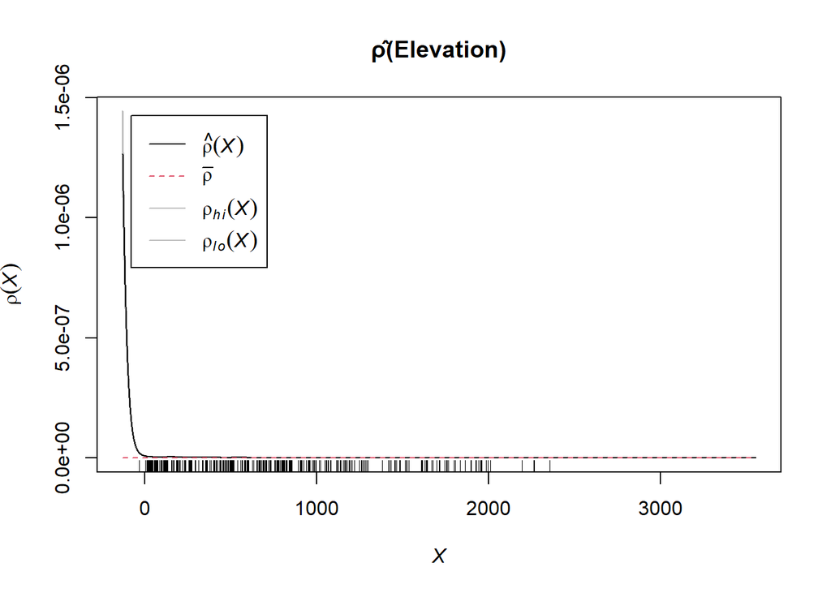

```r
rho_elev <- rhohat(unmark(ppp_bombus), data_covariates$Elevation)
plot(rho_elev, main = "ρ̂(Elevation)")
```

The estimated intensity appears highest at low elevations, but that spike is likely not meaningful — possibly due to edge effects or sparse data near the boundaries.

#### Covariate Relationship – Forest Cover

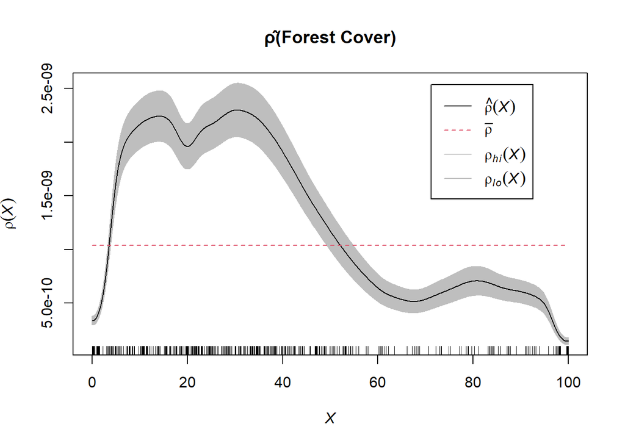

```r
ppp_unmarked <- unmark(ppp_bombus)
rho_forest <- rhohat(ppp_unmarked, data_covariates$Forest)
plot(rho_forest, main = "ρ̂(Forest Cover)")
```

For forest cover, intensity peaks between 10% and 35%, suggesting Bombus prefer areas with low to moderate vegetation — likely open habitats or meadow edges.

#### Elevation Binning + Histogram Overlay

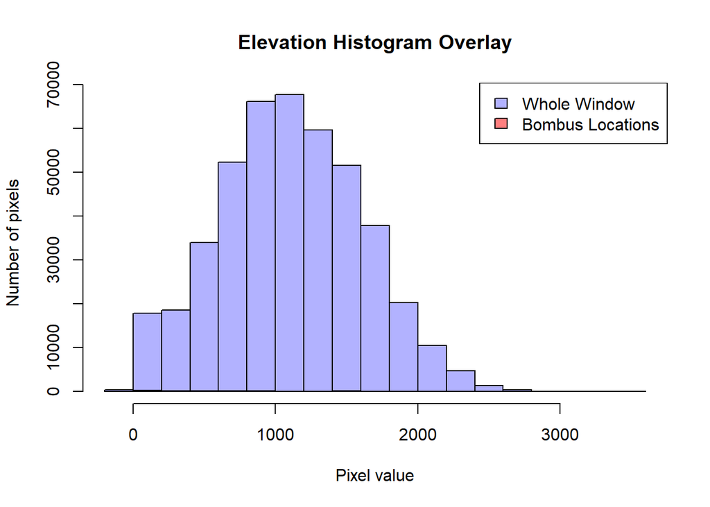

```r
elev <- data_covariates$Elevation

hist(elev, col = rgb(0, 0, 1, 0.3), main = "Elevation Histogram Overlay")
hist(elev[ppp_bombus], col = rgb(1, 0, 0, 0.5), add = TRUE)
legend("topright", legend = c("Whole Window", "Bombus Locations"),
       fill = c(rgb(0, 0, 1, 0.3), rgb(1, 0, 0, 0.5)))
```

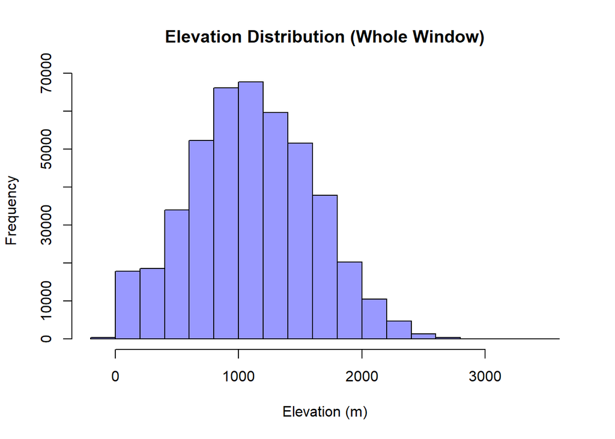

```r
# Convert elevation image to full vector
elev_full <- as.vector(data_covariates$Elevation$v)

# Extract elevation values at Bombus locations, removing any NAs
elev_bombus <- lookup.im(data_covariates$Elevation, ppp_bombus)
elev_bombus <- elev_bombus[!is.na(elev_bombus)]

# Define common bin breaks for comparison
common_breaks <- seq(-200, 3600, by = 200)

# Plot elevation distribution for the whole window
hist(elev_full, col = rgb(0, 0, 1, 0.4), breaks = common_breaks,
     main = "Elevation Distribution (Whole Window)", xlab = "Elevation (m)")
```

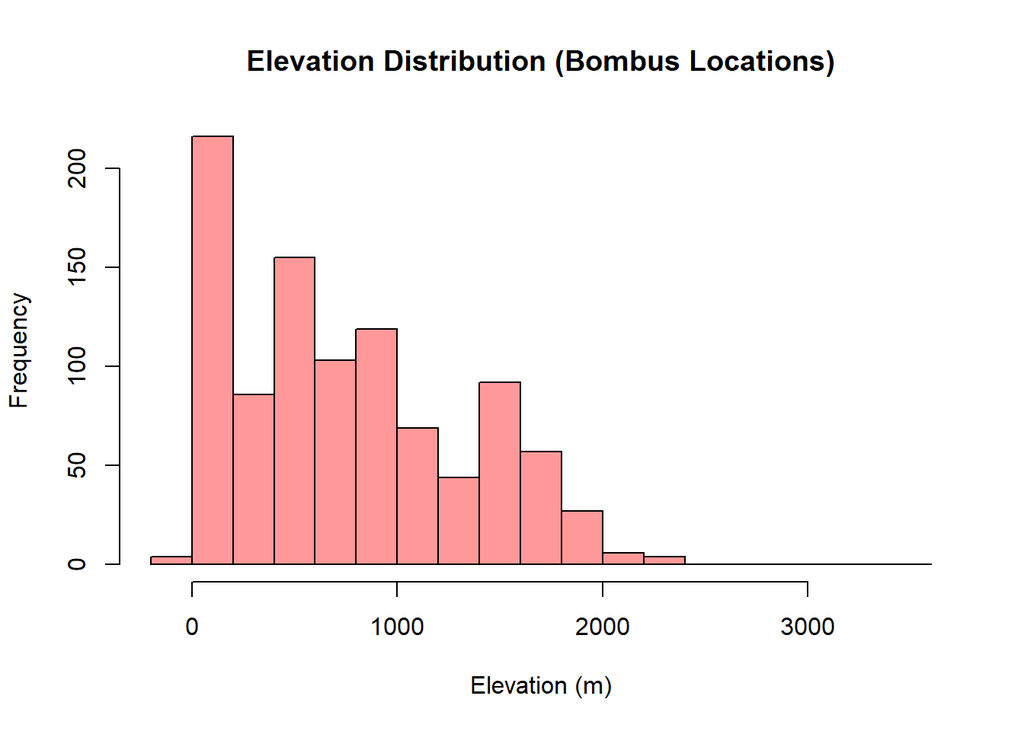

```r
# Plot elevation distribution at Bombus locations
hist(elev_bombus, col = rgb(1, 0, 0, 0.4), breaks = common_breaks,
     main = "Elevation Distribution (Bombus Locations)", xlab = "Elevation (m)")
```

To assess elevation preferences, we first overlaid histograms. However, due to scale mismatch, separate histograms using common breaks were plotted. The elevation histogram helps clarify: most of the region lies at mid-elevation, but Bombus tend to occur more frequently at lower elevations.

#### Intensity Section Summary:

Bombus distribution across BC is not uniform. The point pattern shows clear southern clustering, with preferences for low to mid elevations and moderate forest cover. These findings reject the assumption of CSR and justify intensity-based modeling using covariates.

### II. Spatial Correlations (Second-order Properties)

#### Morisita’s Index

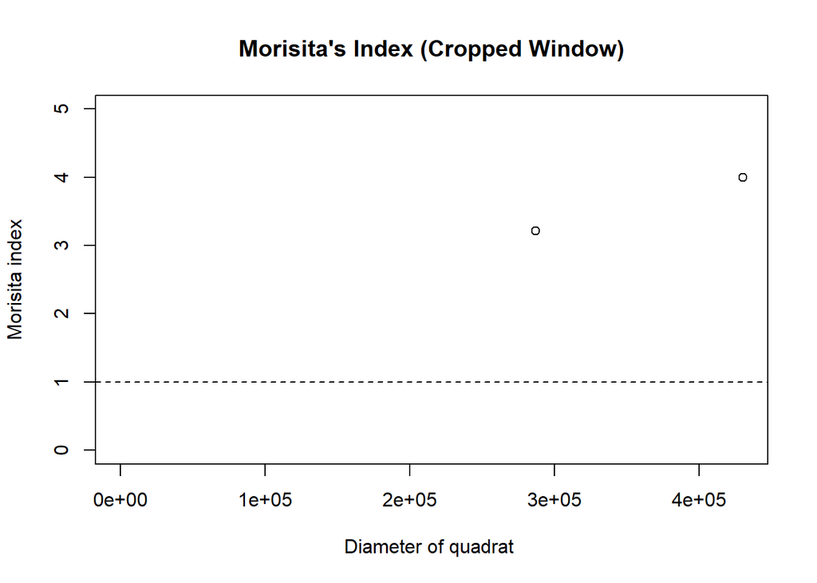

```r
sub_win <- as.owin(c(300000, 800000, 500000, 1200000))
ppp_crop <- ppp_bombus[sub_win]
miplot(ppp_crop, ylim = c(0, 5), main = "Morisita's Index (Cropped Window)")
```

Due to the irregular shape of the observation window, we computed Morisita’s Index using a cropped rectangular subset. Despite evaluating only two distance bands, the index is consistently above 1, suggesting moderate clustering. It supports other correlation-based findings as a supplementary indicator.

#### Ripley’s K-function (Homogeneous)

```r
E_K <- envelope(ppp_bombus, Kest, nsim = 99, correction = "border", fix.n = TRUE)
```

```
## Generating 99 simulations of CSR with fixed number of points  ...
## 1, 2, 3, 4, 5, 6, 7, 8, 9, 10, 11, 12, 13, 14, 15, 16, 17, 18, 19, 20,
## 21, 22, 23, 24, 25, 26, 27, 28, 29, 30, 31, 32, 33, 34, 35, 36, 37, 38, 39, 40,
## 41, 42, 43, 44, 45, 46, 47, 48, 49, 50, 51, 52, 53, 54, 55, 56, 57, 58, 59, 60,
## 61, 62, 63, 64, 65, 66, 67, 68, 69, 70, 71, 72, 73, 74, 75, 76, 77, 78, 79, 80,
## 81, 82, 83, 84, 85, 86, 87, 88, 89, 90, 91, 92, 93, 94, 95, 96, 97, 98,
## 99.
##
## Done.
```

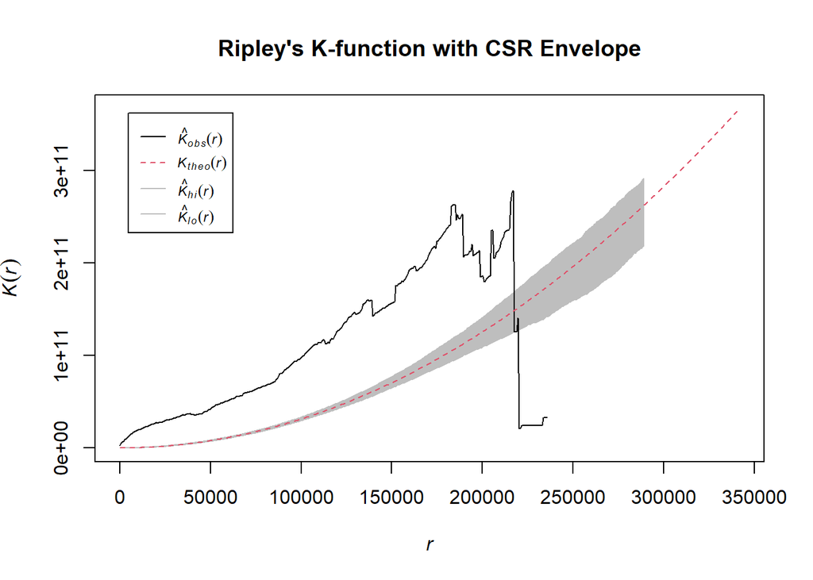

```r
plot(E_K, main = "Ripley's K-function with CSR Envelope", legendargs = list(cex = 0.7))
```

The empirical K function lies above the CSR envelope, showing that Bombus locations are more clustered than expected under randomness across multiple distance scales.

#### Ripley’s K-function (Inhomogeneous)

```r
lambda_bombus <- density(ppp_bombus, sigma = bw.ppl, positive = TRUE)

K_inhom <- envelope(ppp_bombus, Kinhom,
                    simulate = expression(rpoispp(lambda_bombus)),
                    nsim = 99, correction = "border")
```

```
## Generating 99 simulations by evaluating expression  ...
## 1, 2, 3, 4, 5, 6, 7, 8, 9, 10, 11, 12, 13, 14, 15, 16, 17, 18, 19, 20,
## 21, 22, 23, 24, 25, 26, 27, 28, 29, 30, 31, 32, 33, 34, 35, 36, 37, 38, 39, 40,
## 41, 42, 43, 44, 45, 46, 47, 48, 49, 50, 51, 52, 53, 54, 55, 56, 57, 58, 59, 60,
## 61, 62, 63, 64, 65, 66, 67, 68, 69, 70, 71, 72, 73, 74, 75, 76, 77, 78, 79, 80,
## 81, 82, 83, 84, 85, 86, 87, 88, 89, 90, 91, 92, 93, 94, 95, 96, 97, 98,
## 99.
##
## Done.
```

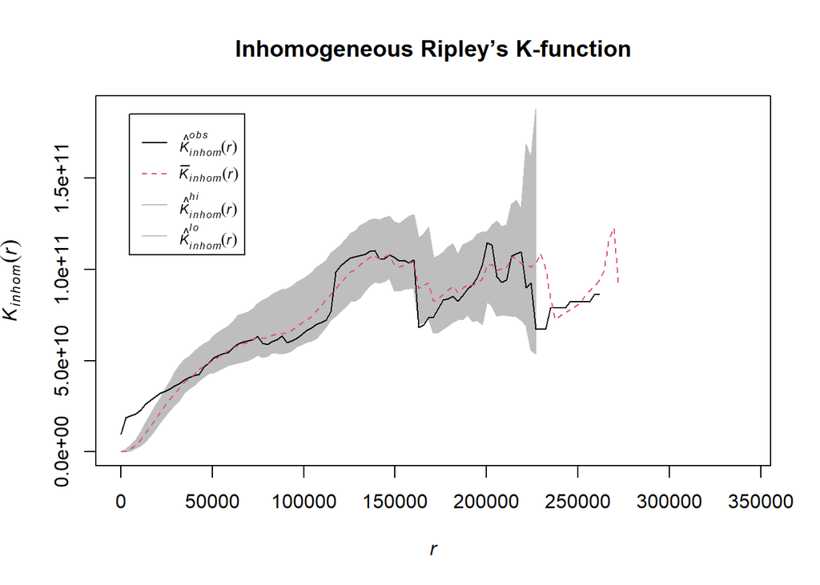

```r
plot(K_inhom, main = "Inhomogeneous Ripley’s K-function", legendargs = list(cex = 0.7))
```

In the K-function plot, the observed line mostly stays within the confidence band and closely follows the theoretical expectation, with only minor deviations. This suggests weak residual clustering after adjusting for intensity.

#### Pair Correlation Function (Homogeneous)

```r
ppp_unmarked <- unmark(ppp_bombus)

r_vals <- seq(0, 100000, length.out = 128)

g_homo <- envelope(
  ppp_unmarked,
  fun = function(X, r, ...) pcf(X, r = r, ...),
  r = r_vals,
  nsim = 99,
  fix.n = TRUE
)
```

```
## Generating 99 simulations of CSR with fixed number of points  ...
## 1, 2,  [8:16 remaining] 3,
##  [8:21 remaining] 4,  [8:28 remaining] 5,  [8:25 remaining] 6,
##  [8:15 remaining] 7,  [8:22 remaining] 8,  [8:06 remaining] 9,
##  [7:59 remaining] 10,  [8:03 remaining] 11,  [7:56 remaining] 12,
##  [7:52 remaining] 13,  [7:48 remaining] 14,  [7:44 remaining] 15,
##  [7:36 remaining] 16,  [7:30 remaining] 17,  [7:24 remaining] 18,
##  [7:19 remaining] 19,  [7:13 remaining] 20,  [7:07 remaining] 21,
##  [7:00 remaining] 22,  [6:53 remaining] 23,  [6:48 remaining] 24,
##  [6:42 remaining] 25,  [6:38 remaining] 26,  [6:32 remaining] 27,
##  [6:26 remaining] 28,  [6:20 remaining] 29,  [6:15 remaining] 30,
##  [6:09 remaining] 31,  [6:03 remaining] 32,  [5:59 remaining] 33,
##  [5:54 remaining] 34,  [5:48 remaining] 35,  [5:42 remaining] 36,
##  [5:37 remaining] 37,  [5:32 remaining] 38,  [5:27 remaining] 39,
##  [5:21 remaining] 40,  [5:16 remaining] 41,  [5:10 remaining] 42,
##  [5:04 remaining] 43,  [4:59 remaining] 44,  [4:55 remaining] 45,
##  [4:49 remaining] 46,  [4:43 remaining] 47,  [4:37 remaining] 48,
##  [4:32 remaining] 49,  [4:27 remaining] 50,  [4:21 remaining] 51,
##  [4:16 remaining] 52,  [4:10 remaining] 53,  [4:05 remaining] 54,
##  [3:59 remaining] 55,  [3:55 remaining] 56,  [3:50 remaining] 57,
##  [3:44 remaining] 58,  [3:39 remaining] 59,  [3:34 remaining] 60,
##  [3:29 remaining] 61,  [3:24 remaining] 62,  [3:18 remaining] 63,
##  [3:13 remaining] 64,  [3:08 remaining] 65,  [3:03 remaining] 66,
##  [2:57 remaining] 67,  [2:52 remaining] 68,  [2:46 remaining] 69,
##  [2:41 remaining] 70,  [2:36 remaining] 71,  [2:30 remaining] 72,
##  [2:25 remaining] 73,  [2:19 remaining] 74,  [2:14 remaining] 75,
##  [2:09 remaining] 76,  [2:04 remaining] 77,  [1:58 remaining] 78,
##  [1:53 remaining] 79,  [1:48 remaining] 80,  [1:42 remaining] 81,
##  [1:37 remaining] 82,  [1:32 remaining] 83,  [1:26 remaining] 84,
##  [1:21 remaining] 85,  [1:15 remaining] 86,  [1:10 remaining] 87,
##  [1:05 remaining] 88,  [59 sec remaining] 89,  [54 sec remaining] 90,
##  [48 sec remaining] 91,  [43 sec remaining] 92,  [38 sec remaining] 93,
##  [32 sec remaining] 94,  [27 sec remaining] 95,  [22 sec remaining] 96,
##  [16 sec remaining] 97,  [11 sec remaining] 98,  [5 sec remaining]
## 99.
##
## Done.
```

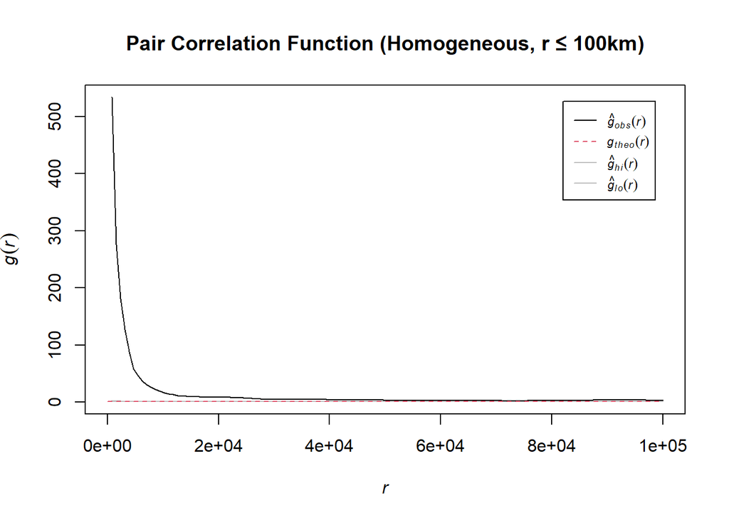

```r
plot(g_homo,
     main = "Pair Correlation Function (Homogeneous, r ≤ 100km)",
     legendargs = list(cex = 0.7),
     legendpos = "topright")
```

g(r) > 1 for r < 30km indicates strong local clustering. At larger distances, the function approaches 1, consistent with weak or no correlation.

#### Pair Correlation Function (Inhomogeneous)

```r
lambda_pos <- density(ppp_bombus, sigma = bw.ppl, positive = TRUE)

g_inhom <- envelope(ppp_bombus, pcfinhom,
                    simulate = expression(rpoispp(lambda_pos)),
                    nsim = 99)
```

```
## Generating 99 simulations by evaluating expression  ...
## 1, 2, 3, 4, 5, 6, 7, 8, 9, 10, 11, 12, 13, 14, 15, 16, 17, 18, 19, 20,
## 21, 22, 23, 24, 25, 26, 27, 28, 29, 30, 31, 32, 33, 34, 35, 36, 37, 38, 39, 40,
## 41, 42, 43, 44, 45, 46, 47, 48, 49, 50, 51, 52, 53, 54, 55, 56, 57, 58, 59, 60,
## 61, 62, 63, 64, 65, 66, 67, 68, 69, 70, 71, 72, 73, 74, 75, 76, 77, 78, 79, 80,
## 81, 82, 83, 84, 85, 86, 87, 88, 89, 90, 91, 92, 93, 94, 95, 96, 97, 98,
## 99.
##
## Done.
```

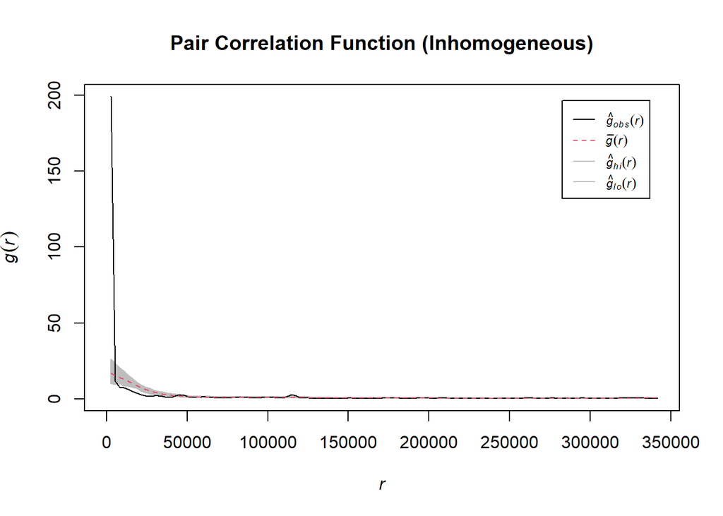

```r
plot(g_inhom,
     main = "Pair Correlation Function (Inhomogeneous)",
     legendargs = list(cex = 0.7),
     legendpos = "topright")
```

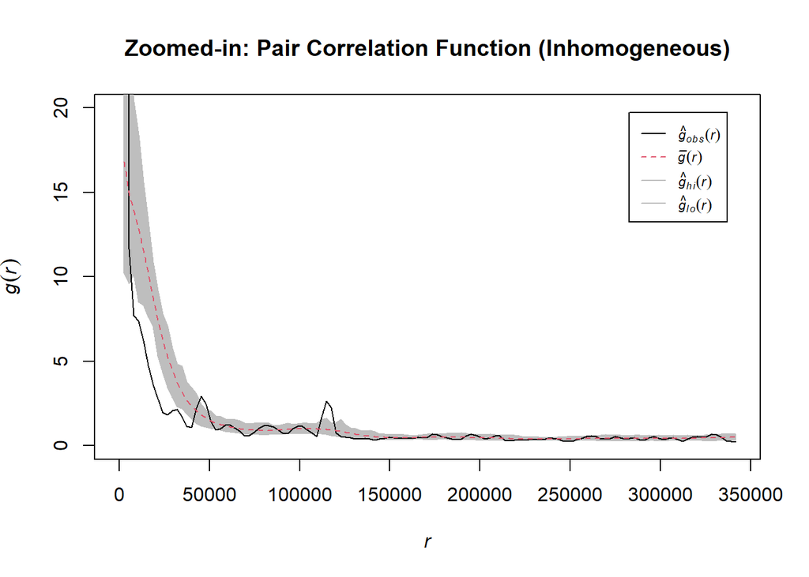

```r
plot(g_inhom,
     main = "Zoomed-in: Pair Correlation Function (Inhomogeneous)",
     ylim = c(0, 20),
     legendargs = list(cex = 0.7),
     legendpos = "topright")
```

#### Correlation Section Summary:

Second-order analysis using inhomogeneous Ripley’s K and pair correlation functions shows that Bombus are clustered in southern BC, especially in low to mid elevations and moderately forested areas. However, most of this clustering appears to be explained by environmental covariates like elevation and forest cover, with only limited residual spatial dependence beyond those factors.

#### Overall Summary:

Our spatial analysis of Bombus distribution in BC reveals clear clustering in southern regions, particularly in low to mid elevations and moderately forested areas.

First-order and second-order analyses together suggest that most spatial variation is shaped by environmental covariates, with only minimal clustering beyond what those covariates explain.

These findings highlight how ecological factors like elevation and forest cover shape Bombus habitats — and support covariate-based modeling for future ecological or conservation efforts.